# PM2.5 Forecasting

# Diagnose the result

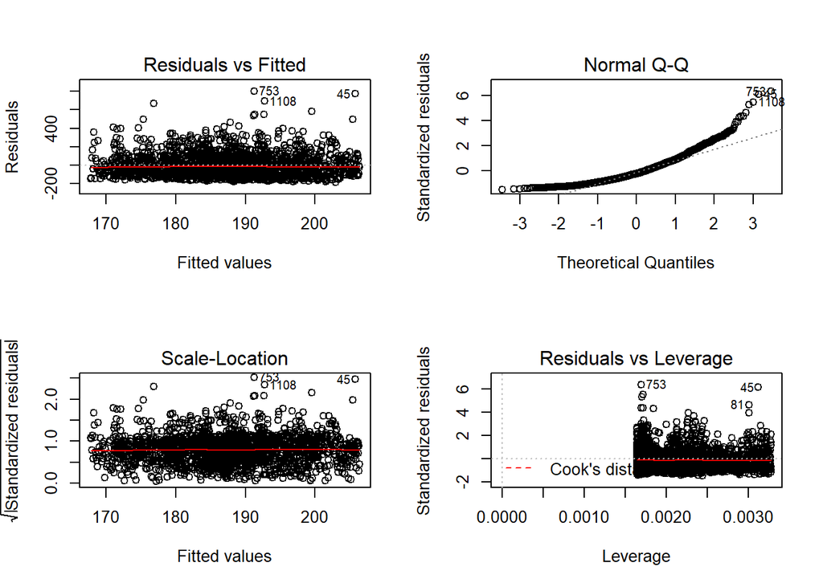

```r
par(mfrow = c(2,2))
plot(pm2.5.ts.trend.seasonal)
```

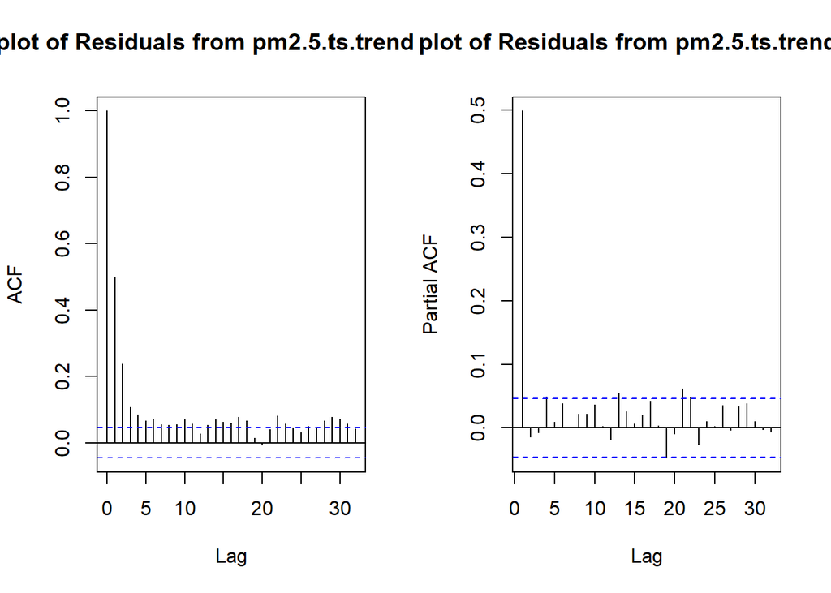

```r
par(mfrow = c(1,2))
acf(pm2.5.ts.trend.seasonal$residuals, main = "ACF plot of Residuals from pm2.5.ts.trend.seasonal")
pacf(pm2.5.ts.trend.seasonal$residuals, main = "PACF plot of Residuals from pm2.5.ts.trend.seasonal")
```

```r
par(mfrow=c(1,1))
shapiro.test(pm2.5.ts.trend.seasonal$residuals)
```

```
##
##  Shapiro-Wilk normality test
##
## data:  pm2.5.ts.trend.seasonal$residuals
## W = 0.90259, p-value < 2.2e-16
```

# The p-value of Shapiro-Wilk normality test is less than 0.05 implying that residual is significantly not normally distributed, which violates assumption of linear regression. Then we use box cox transformation to normalize the data, and then refit the linear model. And still acf plot shows potential seasonality.

# Box-cox transformation

```r
L <- boxcox(pm2.5.ts.trend.seasonal, plotit = F)$x[which.max(boxcox(pm2.5.ts.trend.seasonal, plotit = F)$y)]
pm2.5.ts.trend.seasonal1 <- lm(pm2.5.ts^L ~ pm2.5.ts.days + sin(2*pi*pm2.5.ts.days/7) + cos(2*pm2.5.ts.days/7))
summary(pm2.5.ts.trend.seasonal1)
```

```
##
## Call:
## lm(formula = pm2.5.ts^L ~ pm2.5.ts.days + sin(2 * pi * pm2.5.ts.days/7) +
##     cos(2 * pm2.5.ts.days/7))
##
## Residuals:
##     Min      1Q  Median      3Q     Max
## -2.8710 -0.6531  0.0033  0.6640  3.3547
##
## Coefficients:
##                                 Estimate Std. Error t value Pr(>|t|)
## (Intercept)                    4.664e+00  4.504e-02 103.562  < 2e-16 ***
## pm2.5.ts.days                 -9.280e-05  4.271e-05  -2.173   0.0299 *
## sin(2 * pi * pm2.5.ts.days/7)  6.513e-02  3.183e-02   2.046   0.0409 *
## cos(2 * pm2.5.ts.days/7)       1.419e-01  3.183e-02   4.459 8.72e-06 ***
## ---
## Signif. codes:  0 '***' 0.001 '**' 0.01 '*' 0.05 '.' 0.1 ' ' 1
##
## Residual standard error: 0.9619 on 1822 degrees of freedom
## Multiple R-squared:  0.01555,    Adjusted R-squared:  0.01393
## F-statistic: 9.593 on 3 and 1822 DF,  p-value: 2.767e-06
```

# Diagnose the model

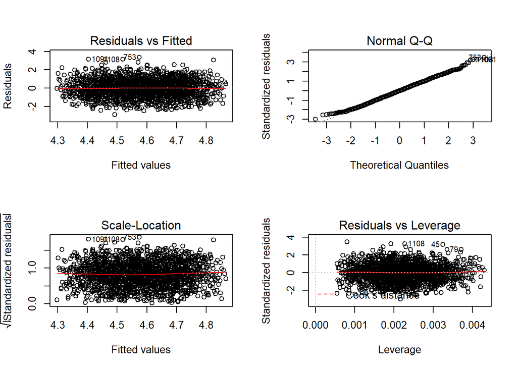

```r
par(mfrow = c(2,2))
plot(pm2.5.ts.trend.seasonal1)
```

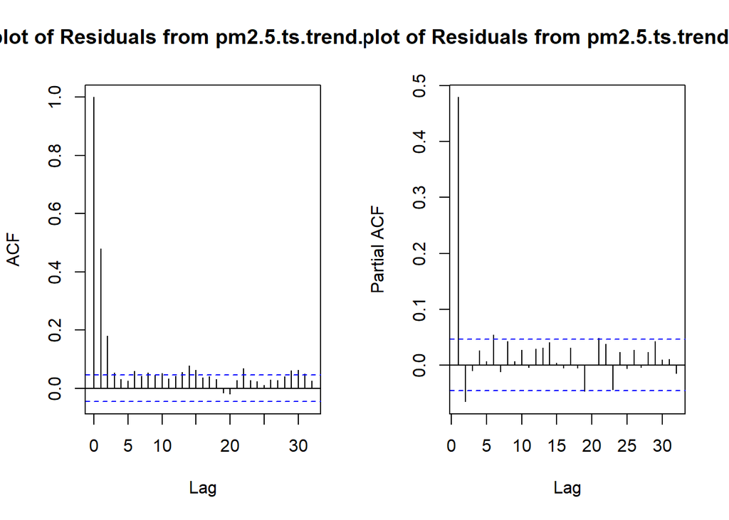

```r
par(mfrow = c(1,2))
acf(pm2.5.ts.trend.seasonal1$residuals, main = "ACF plot of Residuals from pm2.5.ts.trend.seasonal1")
pacf(pm2.5.ts.trend.seasonal1$residuals, main = "PACF plot of Residuals from pm2.5.ts.trend.seasonal1")
```

```r
par(mfrow=c(1,1))
shapiro.test(pm2.5.ts.trend.seasonal1$residuals)
```

```
##
##  Shapiro-Wilk normality test
##
## data:  pm2.5.ts.trend.seasonal1$residuals
## W = 0.99828, p-value = 0.05453
```

# The p-value of Shapiro-Wilk normality test is bigger than 0.05 implying that the residual confers to normal distribution, which agree with assumption of linear regression.

# Build the arima model of the residual of the linear model of the pm2.5 time series

```r
pm2.5.ts.autoarima <- auto.arima(pm2.5.ts.trend.seasonal1$residuals)
summary(pm2.5.ts.autoarima)
```

```
## Series: pm2.5.ts.trend.seasonal1$residuals
## ARIMA(3,0,3) with zero mean
##
## Coefficients:
##          ar1     ar2      ar3     ma1      ma2      ma3
##       0.3495  0.8731  -0.2568  0.1605  -0.8612  -0.2017
## s.e.  0.0725  0.0776   0.0559  0.0726   0.0584   0.0464
##
## sigma^2 estimated as 0.7037:  log likelihood=-2267.31
## AIC=4548.62   AICc=4548.68   BIC=4587.19
##
## Training set error measures:
##                         ME     RMSE       MAE     MPE     MAPE      MASE
## Training set -0.0001160445 0.837482 0.6462517 81.7431 227.1895 0.8889572
##                      ACF1
## Training set 0.0009836837
```

# Diagnose the model

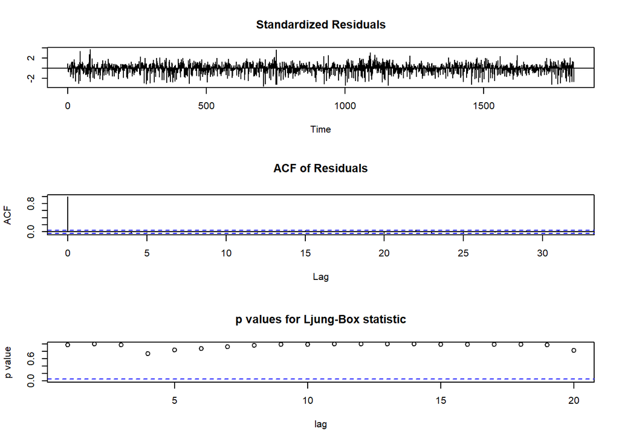

```r
tsdiag(pm2.5.ts.autoarima,gof.lag=20)
```

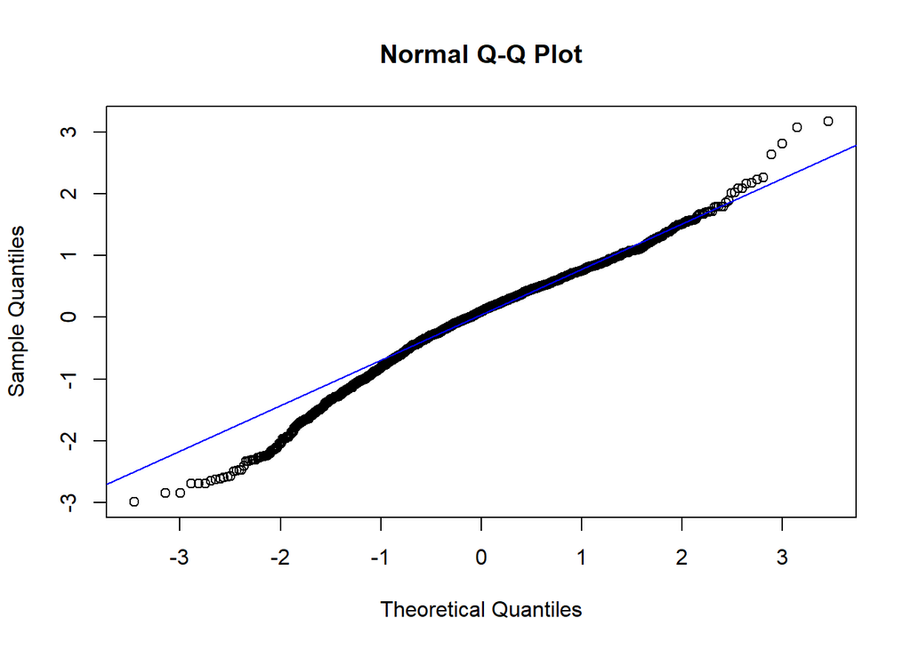

```r
qqnorm(pm2.5.ts.autoarima$residuals)
qqline(pm2.5.ts.autoarima$residuals,col="blue")
```

```r
shapiro.test(pm2.5.ts.autoarima$residuals)
```

```
##
##  Shapiro-Wilk normality test
##
## data:  pm2.5.ts.autoarima$residuals
## W = 0.98002, p-value = 2.755e-15
```

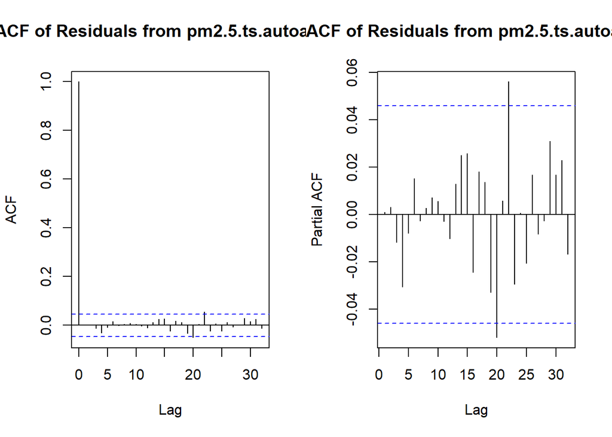

```r
par(mfrow=c(1,2))
acf(pm2.5.ts.autoarima$residuals, main="ACF of Residuals from pm2.5.ts.autoarima")
pacf(pm2.5.ts.autoarima$residuals,main="PACF of Residuals from pm2.5.ts.autoarima")
```

```r
par(mfrow=c(1,1))
Box.test(pm2.5.ts.autoarima$residuals,type="Ljung-Box")
```

```
##
##  Box-Ljung test
##
## data:  pm2.5.ts.autoarima$residuals
## X-squared = 0.0017698, df = 1, p-value = 0.9664
```